# Lab 10: Text and Time Analysis

Johnny Tamanaha, Emily Archambault, Kaiyuan Fan, Eugene Miller, Jingzhi Zhang

11/3/2019

## Timeliness of the Answer as a Feature

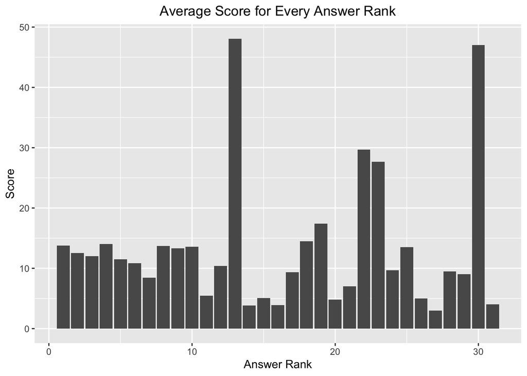

From this plot, it does not appear as though the timeliness of an answer has any correlation to the score it receives.

Does the data for scores follow a normal distribution? We will create a histogram of scores to determine if the data follows a normal distribution.

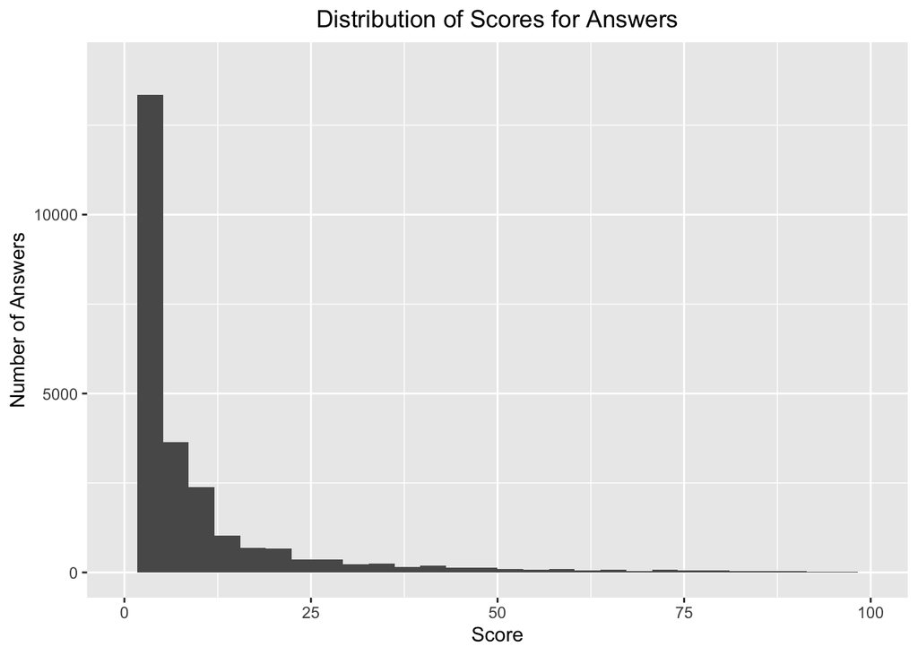

From this plot we can see that scores to not follow a normal distribution. This means that Z scores and percentiles will not have the same meaning that they would if the data was normal. The relationship between Z score and percentile is not preserved.

## Individual Sections

### Eugene Miller

The feature of the text that I am measuring is whether a code chunk was included in a question or answer. That is, whether the string `"<code>"` is in a question or an answer.

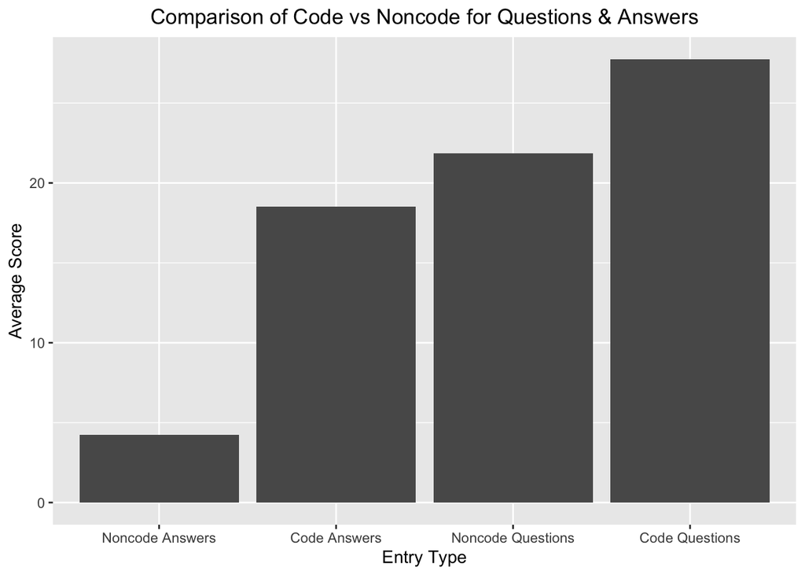

The proportion of questions that invoke the `"<code>"` string is 0.5953 and the proportion for answers is 0.601425.

The mean score for a question without code is 21.8369162, however if the poster includes code in their question it is 27.7450025. Likewise, for a answer with no code the mean score is 4.2338958 and if code is included 18.5056325. Therefore both good questions and good answers include code. This makes sense, as Stackoverflow is a forum based on coding questions. Communicating directly via code is more relevant to the theme of the board, and this is why posts involving code have a higher average score.

### Jingzhi Zhang

The feature of the text that I am measuring is the number of paragraphs that were included in a question or an answer. That is, weather the string `"<p>"` is in a question or an answer.

```
## # A tibble: 40,000 x 8
##       Id OwnerUserId CreationDate        ParentId Score Body   X7    pcount
##    <dbl>       <dbl> <dttm>                 <dbl> <dbl> <chr>  <lgl>  <int>
##  1   497          50 2008-08-02 16:56:53      469     4 "<p>o… NA         3
##  2   518         153 2008-08-02 17:42:28      469     2 "<p>I… NA         1
##  3   536         161 2008-08-02 18:49:07      502     9 "<p>Y… NA         5
##  4   538         156 2008-08-02 18:56:56      535    23 "<p>O… NA         4
##  5   541         157 2008-08-02 19:06:40      535    20 "<p>W… NA         1
##  6   595         116 2008-08-03 01:17:36      594    25 "<p>T… NA         9
##  7   660         197 2008-08-03 12:09:18      535    14 "<p>S… NA         4
##  8   701         111 2008-08-03 14:30:50      683     3 "<p>N… NA         4
##  9   735         145 2008-08-03 15:47:22      683    -2 "<p>I… NA         6
## 10   745         154 2008-08-03 15:59:19      683     8 "<p>A… NA         1
## # … with 39,990 more rows
```

```
## # A tibble: 10,000 x 8
##       Id OwnerUserId CreationDate        Score Title   Body    X7    pcount
##    <dbl>       <dbl> <dttm>              <dbl> <chr>   <chr>   <lgl>  <int>
##  1   469         147 2008-08-02 15:11:16    21 How ca… "<p>I … NA         3
##  2   502         147 2008-08-02 17:01:58    27 Get a … "<p>I … NA         2
##  3   535         154 2008-08-02 18:43:54    40 Contin… "<p>I'… NA         2
##  4   594         116 2008-08-03 01:15:08    25 cx_Ora… "<p>Th… NA         1
##  5   683         199 2008-08-03 13:19:16    28 Using … "<p>I … NA         2
##  6   742         189 2008-08-03 15:55:28    30 Class … "<p><a… NA         3
##  7   766     1384652 2008-08-03 17:44:07    20 Python… "<p>I … NA         2
##  8   773         207 2008-08-03 18:27:09   256 How do… "<p>I … NA         3
##  9   972         145 2008-08-04 02:17:51   364 Adding… "<p>I'… NA         6
## 10  1476          92 2008-08-04 18:20:36   251 How do… "<p>Ho… NA         5
## # … with 9,990 more rows
```

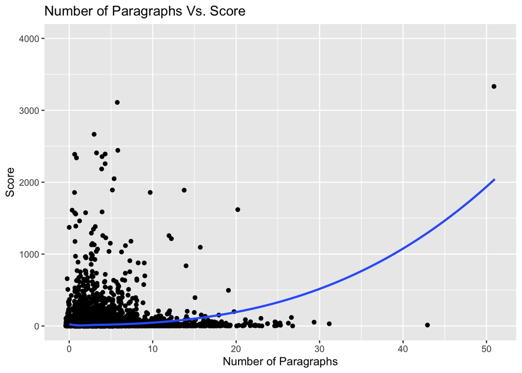

This plot shows the relationships between numbers of paragraphs and score. Althought the line shows that as numbers of paragraph growing up the score is going up too, from the plot we can see that most of the dots gather around between 0 to 10 for x-axis and between 0 to 1000 for y-axis which means writing more paragraphs would not guarantee people get higher score and higher score does not exactly depend on number of paragraphs.

### Johnny Tamanaha

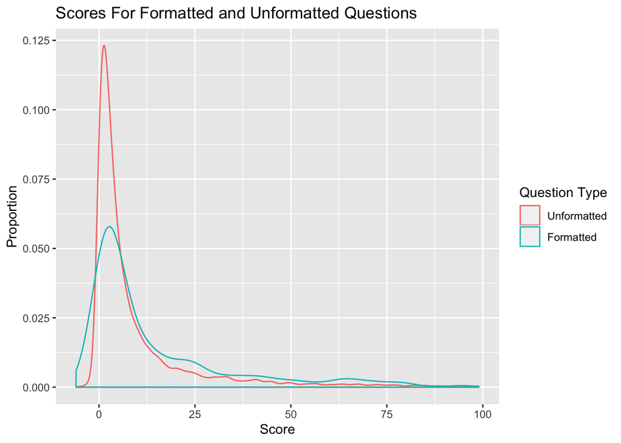

```
## # A tibble: 2 x 7
##   is_question_formatted `30%` `40%` `50%` `60%` `70%` `80%`
##   <lgl>                 <dbl> <dbl> <dbl> <dbl> <dbl> <dbl>
## 1 FALSE                     2     3     4     6   9      16
## 2 TRUE                      3     4     7    13  23.4    44
```

The feature thaI I analyzed for questions was whether a question was well-formatted or not. I defined “well-formatted” as questions where the first paragraph starts with “How” and ends with “?”. I chose this feature because I wanted to see the effect that question quality has on its score. There seems to be a positive relationship between question quality and score. From my plot, the proportion of scores is skewed right for non-well-formatted questions, while the proportion of scores is visibly less skewed for well-formatted questions. This is also supported by the quantiles for both groups, with well-formatted questions having much higher percentiles across the board.

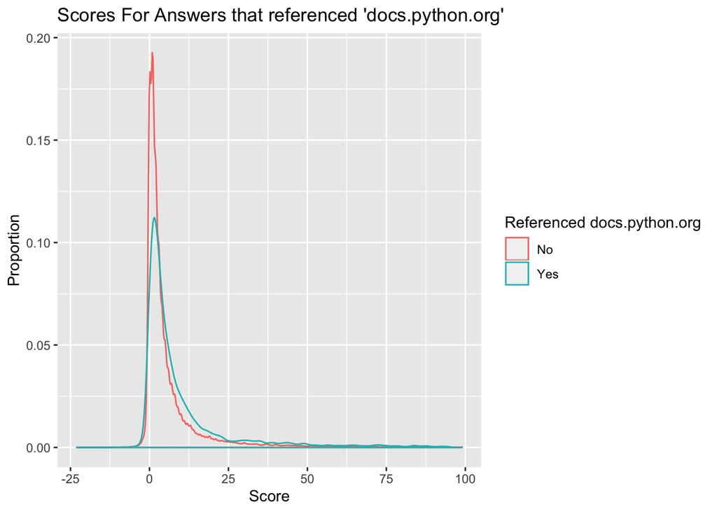

```
## # A tibble: 2 x 7
##   docs_python `30%` `40%` `50%` `60%` `70%` `80%`
##   <lgl>       <dbl> <dbl> <dbl> <dbl> <dbl> <dbl>
## 1 FALSE           1     2     2     3     5     8
## 2 TRUE            2     3     5     7    10    16
```

The feature that I analyzed for answers was whether an answer referenced “http://docs.python.org”. After looking through a lot of the answers, this was a website that seemed to pop up a lot, so I wanted to see if there was a correlation between references to this website and how helpful the answer was. There seems to be a weak positive relationship between referencing the website and answer score. Both proportions are heavily skewed right, but the answers with the website reference have a lot lower peak which indicates that there are less lower scores. This is reflected in the quantiles, where answers with the website reference have higher scores for all relevant quantile intervals.

### Kaiyuan Fan

The feature I measure was whether hyperlink present in Questions or Answers will influence score. To do this, I search the `"</a>"` in the file.

```
## # A tibble: 10,000 x 9
##       Id OwnerUserId CreationDate        Score Title Body  X7    pcount
##    <dbl>       <dbl> <dttm>              <dbl> <chr> <chr> <lgl>  <int>
##  1   502         147 2008-08-02 17:01:58    27 Get … "<p>… NA         2
##  2   742         189 2008-08-03 15:55:28    30 Clas… "<p>… NA         3
##  3   766     1384652 2008-08-03 17:44:07    20 Pyth… "<p>… NA         2
##  4   773         207 2008-08-03 18:27:09   256 How … "<p>… NA         3
##  5   972         145 2008-08-04 02:17:51   364 Addi… "<p>… NA         6
##  6  1734          59 2008-08-05 00:12:55    20 Any … "<p>… NA         2
##  7  3976         556 2008-08-06 21:00:01    12 Prog… "<p>… NA         6
##  8  5419         207 2008-08-07 22:26:58    72 Pyth… "<p>… NA         4
##  9  5966         745 2008-08-08 14:05:45    10 Best… "<p>… NA        11
## 10 16067         199 2008-08-19 12:32:38    18 Prot… "<p>… NA         4
## # … with 9,990 more rows, and 1 more variable: link <lgl>
```

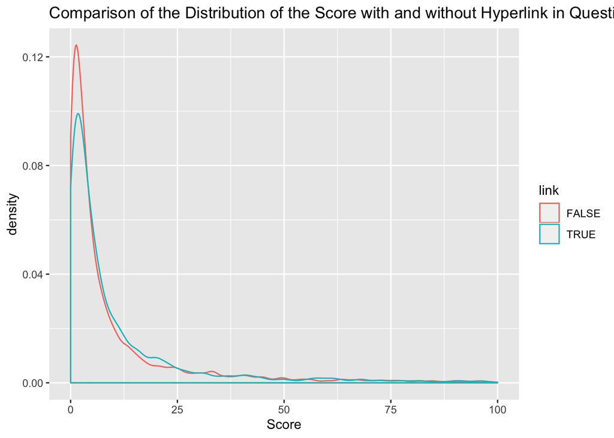

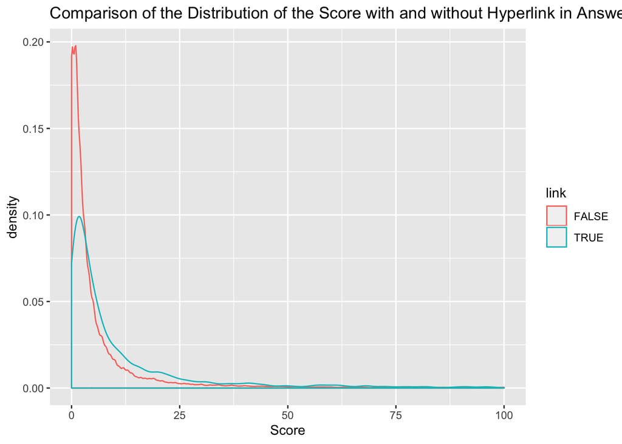

From the plots I got, I find the score is more distribute within the small score when it doesn’t have hyperlink. However, score is more distribute within the bigger score when it does have hyperlink. Therefore, I conclude that hyperlink has positive influence on the score, which increases the score.

### Emily Archambault

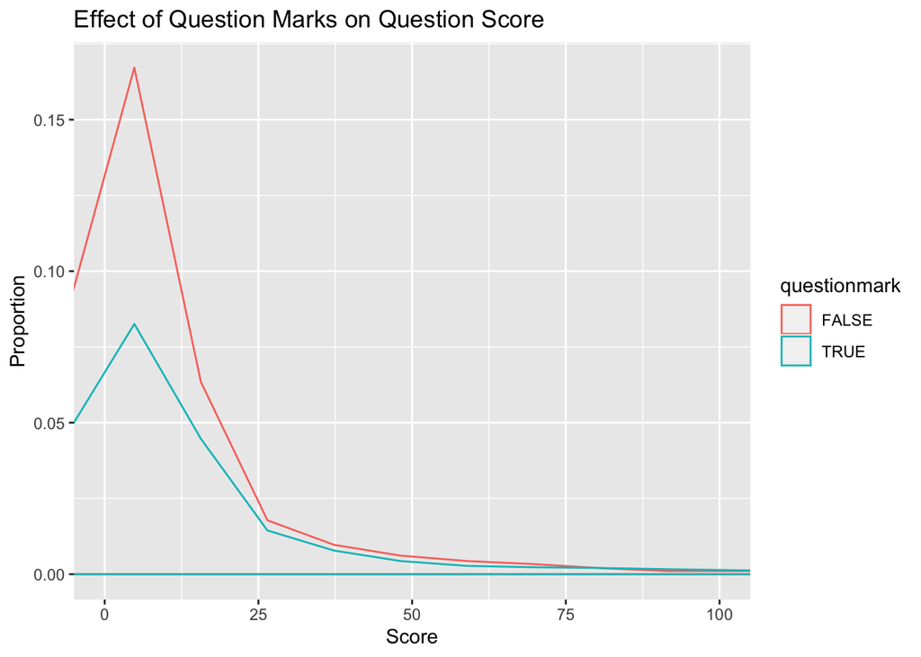

The feature I analyzed for questions was whether or not the title of the question ended with a question mark. My graph indicates that there is a positive correlation between those questions which end with a question mark and a higher score. A question mark could indicate a more direct, specific question that is easier to answer, and to me, seemed to be “friendlier”. I wondered if this was a trend that could impact the overall score, and it appears that it does.

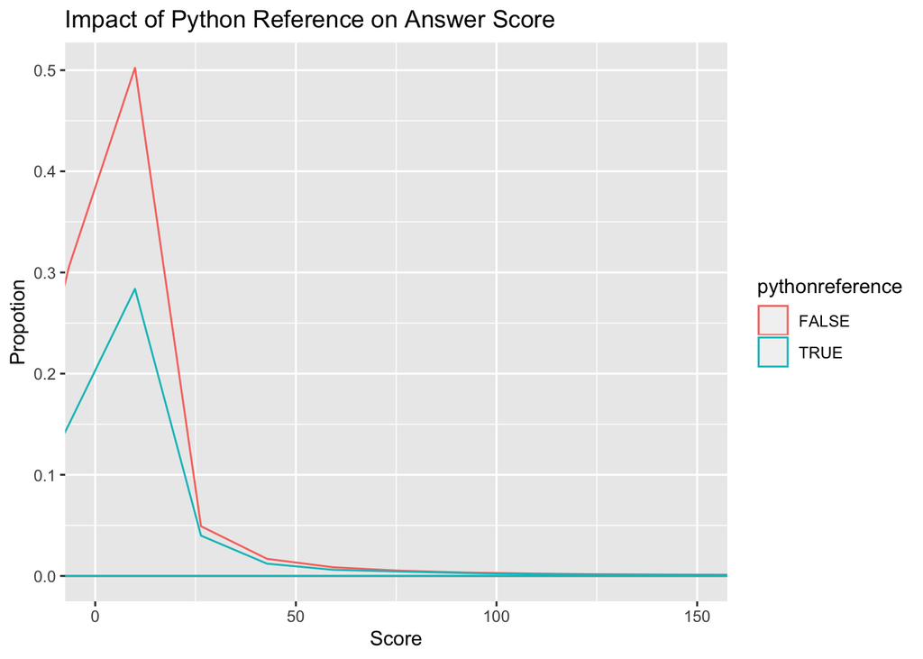

The feature I examined for answers was whether or not the answer contained the word “Python”. I noticed while reading through the answers that some were very short and specific, while some gave broader answers, perhaps referencing overall Python behaviors and demonstrating a strong understanding of the program. I wanted to see if a reference to Python impacted the score of the answer, and my graph indicates that it does. This is supported with further data; the average score for an answer containing the word “Python” is 18.9488909 and the average score for an answer without is 10.8321144

## Features that Affect Score

From our individual sections, the feature that affects the score of a question the most is whether or not the question is well-formatted. We see a higher density of these questions having higher scores compared to an average question. A possible reason as to why this leads to a higher question score is that well-formatted questions are more specific and easier to answer than non formatted questions. The plot “Scores For Formatted and Unformatted Questions” supports this finding.

For answers, the features that affected scores the most were whether or not the string `"<code>"` appeared and whether the website “http://docs.python.org” was referenced. A possible reason as to why `"<code>"` positively correlates with score is that these answers give very specific technical answers to the question being asked. If the question is code related, a code answers is the most appropriate format. Referencing “http://docs.python.org” could be a good positive influencer of score because it gives tutorials and methods in python that are direct and to the point, allowing any person asking a question to resolve their issue by themselves.